# DK Forest LiDAR - Forest Annotations & Training Data

Jakob J. Assmann

17/10/2024

This document provides an overview of the forest annotations used for generating the training dataset that forms the base of our forest conservation value models for Denmark.

These annotations are vector polygons of forests in Denmark that are of known “high” or “low” conservation value. We used these polygons to generate a training dataset of 60k pixels based on the 10 m grid of Denmark that is used by our models. The grid is defined by the EcoDes-DK15 dataset. A brief description on how the final pixel training dataset was generated from the forest annotations can be found at the end of this document.

Note: What makes a “high” or “low” conservation value forest is to some degree arbitrary. Our definitions here are the result of a long discussion and have been developed over multiple years. The aim was to arrive at a workable definition that aligns with the current framework of forest designations in Denmark, while also ensuring that enough training data is available. We appreciate that our chosen definitions of forest conservation value are a simplification and not without flaws (e.g., we assume that all “plantations” are of low forest conservation value).

## High conservation value forests

Total number of high conservation value forest polygons: 9400.

### §25 and §15 forest

The core of the high conservation value forest annotations is made up by the polygons for the designated §25 (“naturmaessigt saerlig vaerdifuld skov”) and §15 (“skovnatur”) forests. The vector boundaries of these forests were retrieved from “Danmarks Miljøportal” (https://arealinformation.miljoeportal.dk/):

- p25_offentligareal.shp (§25 forests, accessed on on 5 April 2019
- skov_kortlaegning_2016_2018.shp (§15 forests, accessed 24 September 2019).

Number of forests: 9044 (§25 forests: 2906; and §15 forests: 6138).

### Untouched forests and “aftaler om natur”

The two other components of the high conservation value forest annotations are vector boundaries from the untouched forests (private and public), as well as areas with agreements on nature (“aftaler om natur”). The vector boundaries of these areas were retrieved from “Miljøgis - Ansøgning om skovtilskud for private” (https://miljoegis3.mim.dk/spatialmapsecure?profile=privatskovtilskud):

- tilsagn17_st_uroert_skov_privat_tilskud.shp (untouched forests, accessed on 6 July 2021)
- tilsagn18_st_uroert_skov.shp (untouched forests, accessed on 6 July 2021)
- tilsagn19_st_uroert_skov_privat_tilskud.shp (untouched forests, accessed on 6 July 2021)
- tilsagn20_st_uroert_skov_privat_tilskud.shp (untouched forests, accessed on 6 July 2021)
- aftale_natur_tinglyst.shp (agreements on nature, accessed on 6 July 2021)

Number of forests: 356 (“untouched”: 118; “aftaler om natur”: 238).

## Low conservation value forests

Total number of low conservation value forest polygons: 10697.

### “Ikke” §25 forests

These forests are forests that were considered for being designated as §25 forests, but did not meet the requirements (e.g., after completion of the field survey). The vector geometries for these forests were shared with us by Bjarne Aabrandt Jensen (Miljøstyrelsen) in a personal communication on 19 November 2019.

- ikkeP25_skov.shp (personal communication, 19 November 2019)

Number of forests: 5848.

### NST plantations

These forests are plantations owned by Denmark’s environment agency “Naturstyrelsen” (NST). The vector geometries and auxiliary data for these forests were obtained by personal communication from Bjørn Ole Ejlersen at NST to Pil Pedersen on 11 June 2020.

The source dataset includes all forests owned by NST. To subset only forests that are plantations, we filtered the data by excluding all forests that had an “ANV 4” value of 1, were classified as “urørt” or designated as “historical”. We then sub-sampled the plantations to ensure a balanced training dataset between high and low conservation value forests (target :~10k high & ~10k low conservation value forests). We drew a sample of 5000 plantations. To account for variation within stand ages, we stratified the sample based on the following stand ages classes (years): [0, 10], (10, 25], (25, 50], (50, 75], (75, ∞). For each stand age we drew 1000 forests at random. Not all forests that were drawn in the sample had an associated polygon in the separate vector geometry file (n missing = 151), these forests were not included in the final NST plantation subset.

- NST 2019 08012019 ber 16012020 til bios_au.xlsx (NST forests data table)
- LitraPolygoner_region.shp (NST forests polygons)

Number of forests: 4849.

## Cleaning and preparation of geometries

We observed some overlap between the assembled annotations for high and low conservation value forests. This overlap included duplicate mappings within each category, as well as some duplicate mapping of parts of forests as high and low conservation value. These inaccuracies were expected given the extent of the dataset and the fact that it was assembled from multiple sources. To address the issue we carried out a systematic cleaning of the geometries (fully reproducible through our source code).

First, we removed all internal overlap within the high conservation value geometries. For this we iteratively removed all internal overlap starting with the p25 forests (internally sorted in the order the polygons were loaded), followed by the private old growth and lastly the p15 forests. We also buffered the geometries, using a negative buffer of 10 cm to avoid line-overlaps due to inaccuracies in the geometries. Finally, we removed one remaining p15 forest that failed to be filtered out.

The resulting dataset consisted of two type of forest annotations (8915 high and 9720 low conservation value polygons) with no internal overlap within or between categories.

## Pixel training dataset

### Pixel sampling

The EcoDes-DK15 dataset uses a version of the Danish national grid that divides terrestrial Denmark into 10 m x 10 m cells / pixels (UTM32). For the training dataset we drew a sample of 30k pixels each from within the high conservation value and the low conservation value forest polygons. Specifically, the sample was based on the EcoDes-DK15 “dtm10_m” descriptor raster). The sample was drawn in the following fashion: First, we drew a random pixel from within each forest polygon (high or low). We then filled in the missing number of pixels to make up 30k for each forest conservation value class (high or low). The filing step was done completely at random, drawing from all remaining pixels available per class. The final dataset of pixels therefore contained 30k unique pixels from each class.

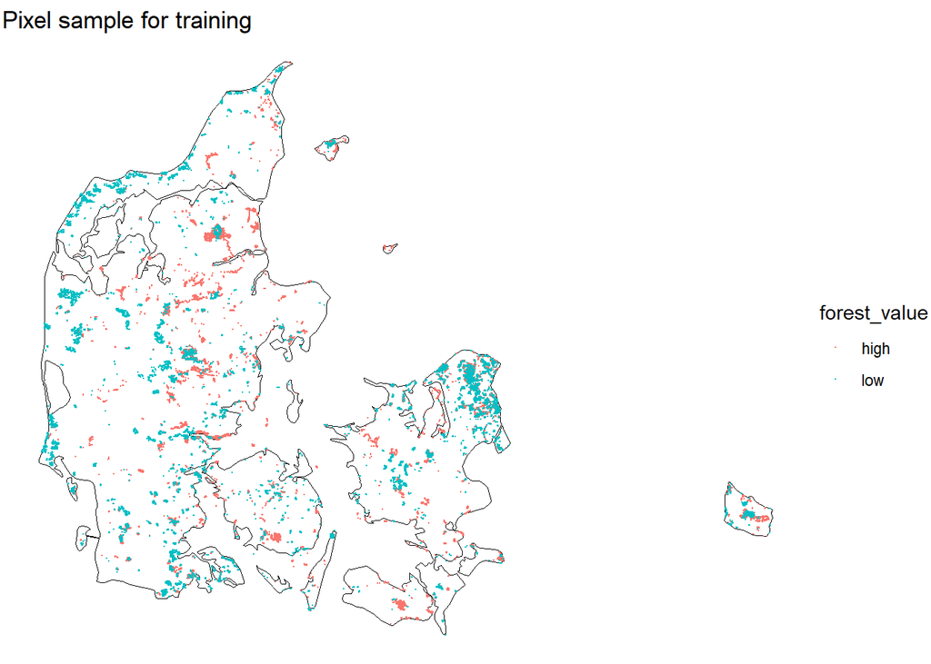

Note, that because of the sampling scheme some pixels will be drawn from the same individual forest polygons and the sampled pixels are therefore to some degree not statistically independent (as would samples from neighbouring polygons). However, the aim of our project is not to carry out a statistical analysis, but to train a machine learning classifier for predicting forest conservation value. The reduction in independence of the samples is therefore not an issue, as long as it does not lead to over fitting of the models (which it did not). Instead sub-sampling of the forest polygons is likely desirable as it allows us to capture the variation within the forest polygons themselves and therefore increase the predictive capabilities of our models. We also include focal (window) predictors variables to account for within landscape-scale (100 m x 100 m) variation in our models.

Finally, we chose a sample size of 60k pixels as a compromise between available computing power and model output performance. There are approximately 56.3 million forest pixels in Denmark and the training sample therefore represents ~0.1% of the total forest area in the country.

### Training / validation split (geographic stratifiaction)

To allow for an independent validation of the model performance, we split the data 80/20 (training / validation) before carrying out the training. To account for potential geographical covariation in the training data we used a geographic stratification when carrying out the split. This means that the split was not conducted at random on the whole dataset, but randomly within regions (80/20 in each region). We used two different stratification schema of Denmark (see below).

#### Biowide stratification

This stratification was developed for the BIOWIDE project (Brunbjerg et al. 2019). The geometries are not publicly available and were kindly shared with us by Ane Brunbjerg (personal communication on 1 September 2021). Some further clean up of the geometries was required on our end. We had to make sure the boundaries of geometries were flush among neighbouring regions and that the coastlines were buffered.

The stratification divides Denmark into six regions.

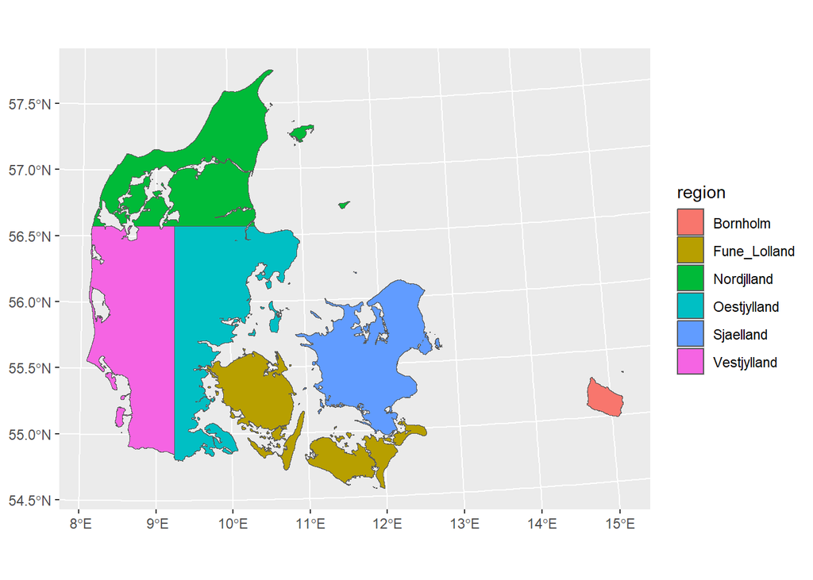

### Derek’s stratification

The second stratification was developed by co-author Derek Corcoran based on climatic and other ecological covariates.

It divides Denmark into three regions.

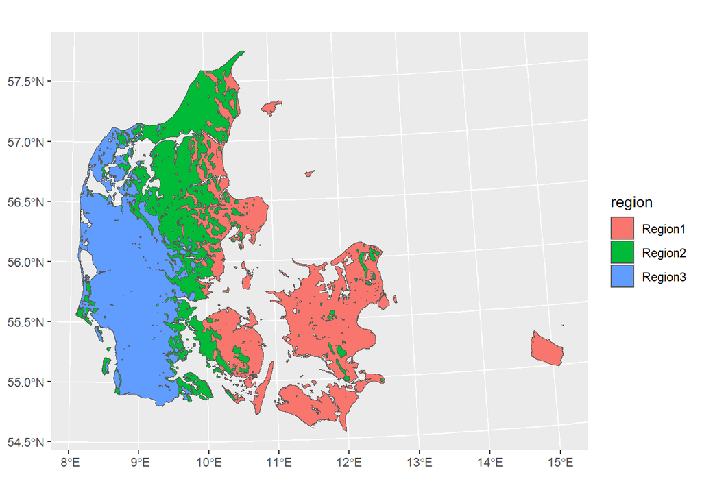

## References

- Brunbjerg, A. K., Bruun, H. H., Brøndum, L., Classen, A. T., Dalby, L., Fog, K., Frøslev, T. G., Goldberg, I., Hansen, A. J., Hansen, M. D. D., Høye, T. T., Illum, A. A., Læssøe, T., Newman, G. S., Skipper, L., Søchting, U., & Ejrnæs, R. (2019). A systematic survey of regional multi-taxon biodiversity: Evaluating strategies and coverage. BMC Ecology, 19(1), 43. https://doi.org/10.1186/s12898-019-0260-x